```python
import pandas as pd
from sklearn.model_selection import train_test_split
from sklearn.tree import DecisionTreeClassifier
from sklearn.metrics import accuracy_score
import matplotlib.pyplot as plt
from sklearn.tree import plot_tree
```

```python
data = pd.read_csv('Data-Week8.csv')
data.head(3)
```

|  | month | day | FFMC | DMC | DC | ISI | temp | RH | wind |
| --- | --- | --- | --- | --- | --- | --- | --- | --- | --- |
| 0 | 1 | sat | 82.1 | 3.7 | 9.3 | 2.9 | 5.3 | 78 | 3.1 |
| 1 | 1 | sun | 18.7 | 1.1 | 171.4 | 0.0 | 5.2 | 100 | 0.9 |
| 2 | 2 | mon | 84.0 | 9.3 | 34.0 | 2.1 | 13.9 | 40 | 5.4 |

1) Make the decision tree for Data of Week 8

```python
X = data[['FFMC','DMC','DC','ISI','temp','RH','wind']]
Y = data[['month']]
```

```python
X_train, X_test, Y_train, Y_test = train_test_split(X,Y,test_size=0.25)
clf = DecisionTreeClassifier()
clf.fit(X_train,Y_train)
```

```
DecisionTreeClassifier()
```

```python
clf.predict(X_test)
```

```
array([ 8,  9,  8,  8,  9,  8,  8,  6,  8,  8,  9,  9,  9,  8,  8,  9,  7,
8,  8,  7,  8,  7,  8, 10,  9,  8,  9,  9,  8,  8,  9,  8,  7,  6,
8, 10,  9,  8,  3,  9,  8,  7,  8,  6,  9,  3,  8,  2,  7,  9,  9,
7,  8,  9,  8,  3,  8,  3,  9,  8,  7,  9,  8,  6,  3,  3,  9,  8,
3,  8,  8,  9,  8,  8,  7,  9,  3,  8,  2,  9,  8,  4,  3,  3,  9,
10,  9,  3,  6,  8,  3,  7,  9,  6,  9,  4,  9,  8,  7,  9,  9,  9,
9,  8,  8,  9,  9,  8,  2,  9,  9,  7,  9,  8,  8,  9,  9,  9,  9,
6,  3,  9, 10,  8,  9,  9,  4,  9,  8,  9])
```

```python
print(accuracy_score(y_true = Y_train,y_pred = clf.predict(X_train)))
print(accuracy_score(y_true = Y_test,y_pred = clf.predict(X_test)))
```

```
1.0
0.8923076923076924
```

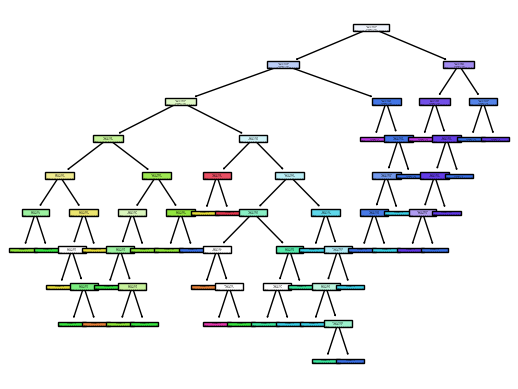

```python
plot_tree(clf,filled=True)
plt.show()
```

```python
tree_structure = clf.tree_
# Make a list of the numbers of the nodes and the corresponding Gini values.
node_data = [(node, tree_structure.impurity[node]) for node in range(tree_structure.node_count)]
for node, gini in node_data:
print(f"Node {node}: Gini = {gini:.4f}")
```

```
Node 0: Gini = 0.7410
Node 1: Gini = 0.7130
Node 2: Gini = 0.7793
Node 3: Gini = 0.5500
Node 4: Gini = 0.4943
Node 5: Gini = 0.4444
Node 6: Gini = 0.0000
Node 7: Gini = 0.0000
Node 8: Gini = 0.3642
Node 9: Gini = 0.6122
Node 10: Gini = 0.0000
Node 11: Gini = 0.3750
Node 12: Gini = 0.0000
Node 13: Gini = 0.0000
Node 14: Gini = 0.0000
Node 15: Gini = 0.2015
Node 16: Gini = 0.4800
Node 17: Gini = 0.4444
Node 18: Gini = 0.0000
Node 19: Gini = 0.4444
Node 20: Gini = 0.0000
Node 21: Gini = 0.0000
Node 22: Gini = 0.0000
Node 23: Gini = 0.0555
Node 24: Gini = 0.0000
Node 25: Gini = 0.0000
Node 26: Gini = 0.7219
Node 27: Gini = 0.1800
Node 28: Gini = 0.0000
Node 29: Gini = 0.0000
Node 30: Gini = 0.5945
Node 31: Gini = 0.5620
Node 32: Gini = 0.6667
Node 33: Gini = 0.0000
Node 34: Gini = 0.5000
Node 35: Gini = 0.0000
Node 36: Gini = 0.0000
Node 37: Gini = 0.2188
Node 38: Gini = 0.5000
Node 39: Gini = 0.0000
```

[output cut: 18 more lines]

```
Node 58: Gini = 0.0000
Node 59: Gini = 0.0000
Node 60: Gini = 0.4576
Node 61: Gini = 0.1921
Node 62: Gini = 0.0000
Node 63: Gini = 0.0480
Node 64: Gini = 0.0165
Node 65: Gini = 0.4444
Node 66: Gini = 0.0000
Node 67: Gini = 0.0000
Node 68: Gini = 0.0000
Node 69: Gini = 0.0000
Node 70: Gini = 0.2188
Node 71: Gini = 0.0000
Node 72: Gini = 0.0000
```

2) Interpret the decision tree based on Gini of each node.

Lower Gini values in the Gini value list show which data points the tree has successfully divided into purer subsets. We may examine how the Gini values vary at each node by closely following the path from the root node to the leaf nodes from left to right. Higher Gini values for nodes indicate that the data is more contaminated and has to be further divided in order to get predictions that are more accurate.

Here, the Node 2 Gini value is 0.77933576, which indicates the highest impurity. As a result, it has to be further split in the same manner as it begins dividing down at each node.

The early splits in the tree are probably indicated by the Gini values that are close to 0.5. Although the data has been split into two categories, there is still a mixture of classes present in these splits because of their moderately impure nodes. Moderate impurities are present in nodes 34,38 and other comparable internal nodes.

Nodes that are directly above leaf nodes, such as 11,15,37 etc., have comparatively fewer impurities.

Finally, the leaf nodes at the end of each branch, such as 6, 7, 10, 12, 13, 14 etc., have 0. 0 values, indicating that the data in these subsets is homogeneous and represents the ultimate conclusion.

3) Find the month with the highest forest fires? Could you find the reason from Tree?

```python
predicted_months = clf.predict(X)
Y_test1 = Y['month'].values
predictions = pd.DataFrame({'ActualMonth': Y_test1, 'PredictedMonth': predicted_months})
count1 = predictions['ActualMonth'].value_counts().reset_index()
count1.columns = ['Month', 'Actual']
count2 = predictions['PredictedMonth'].value_counts().reset_index()
count2.columns = ['Month', 'Predict']
month_counts= pd.merge(count1, count2, on='Month', how='outer').fillna(0)
month_counts.set_index('Month', inplace=True)
maximum_month = month_counts['Actual'].idxmax()
print(month_counts)
print(f'max forest fires month   {maximum_month}')
```

```
         Actual  Predict
Month
8         184      186
9         172      170
3          54       54
7          32       32
2          20       18
6          17       16
10         15       16
4          11       13
12          9        9
1           2        2
11          1        1
max forest fires month   8
```

Thus, by comparing the Actual months with the highest number of forest fires and the predicted months with the help of total data and test data, we were able to determine that the 8th month had the highest number of forest fires and that the prediction for that month had the highest probability.

So, 8th month has the highest forest fires.